# Clustering for scRNA-seq data of CMC D21

Lihui Lin

July 26, 2018

# Clustering CMC D21 data

Here we use two strategies to clustering:  
**1. Seurat:** Detect communitis in Shared Nearest Neighbors network;  
**2. SIMLR:** Single-cell Interpretation via Multi-kernel LeaRning.  
SIMLR is often much precise but slower than Seurat.

## Look through the data

Violin plot below shows:  
- nGene: Number of genes detected (UMI>0) in each cell.  
- nUMI: Number of Unique Molecular Identity identified in each cell.  
- percent.mito: Percentage of mitochondrial genes UMIs in all total UMIs.  
*Note that large number of cells express high level of mitochondrial genes. Is it a reasonable phenomenon for cardiac muscle cells?*

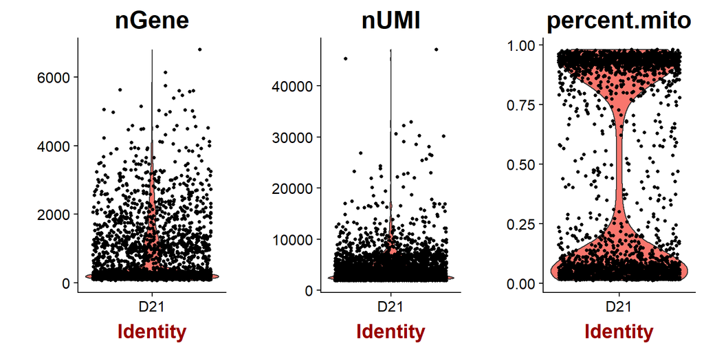

## Seurat clustering

The cells were clustering using [Seurat,2016](https://satijalab.org/seurat/get_started.html). The top 8 PCs were used as imput. No mitochondrion genes were detected as HVG.

Determine statistically significant principal components. We select top 8 pcs for clustering.

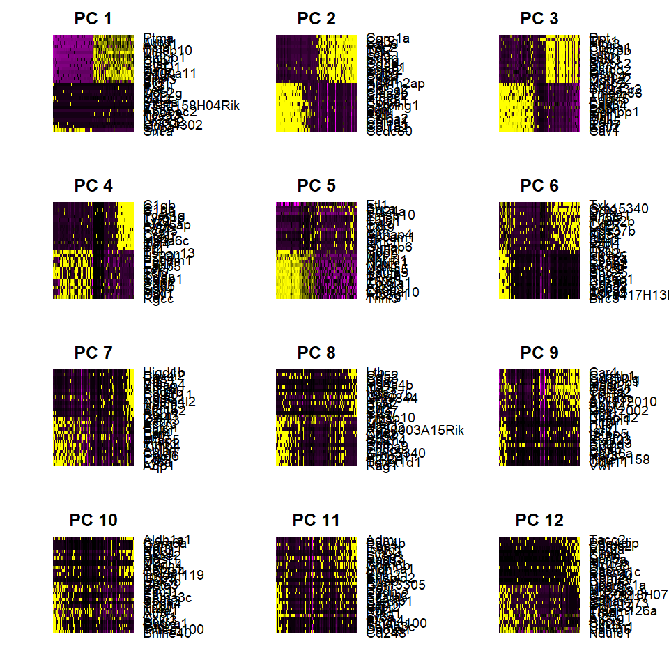

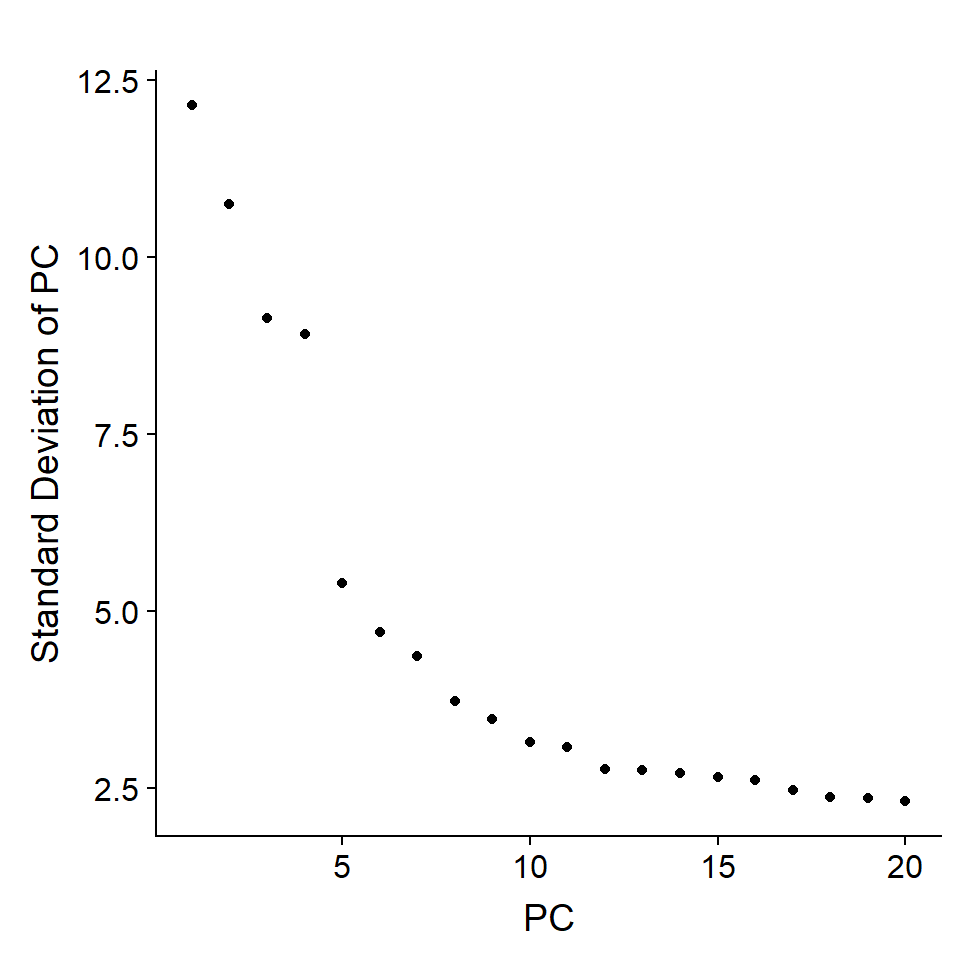

tSNE and UMAP are two non-linear dimention reduction algorithm. The clustering results of **Seurat** are showed. *(Resolution=0.2*)

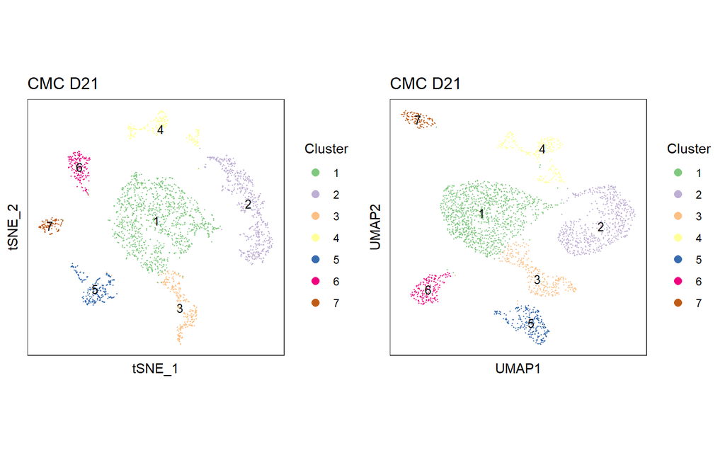

Cardica myoblast markers and hemoglobin

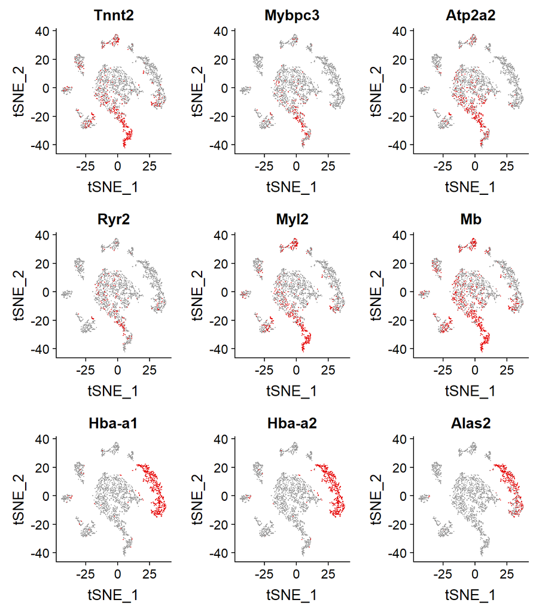

Hematopoietic markers

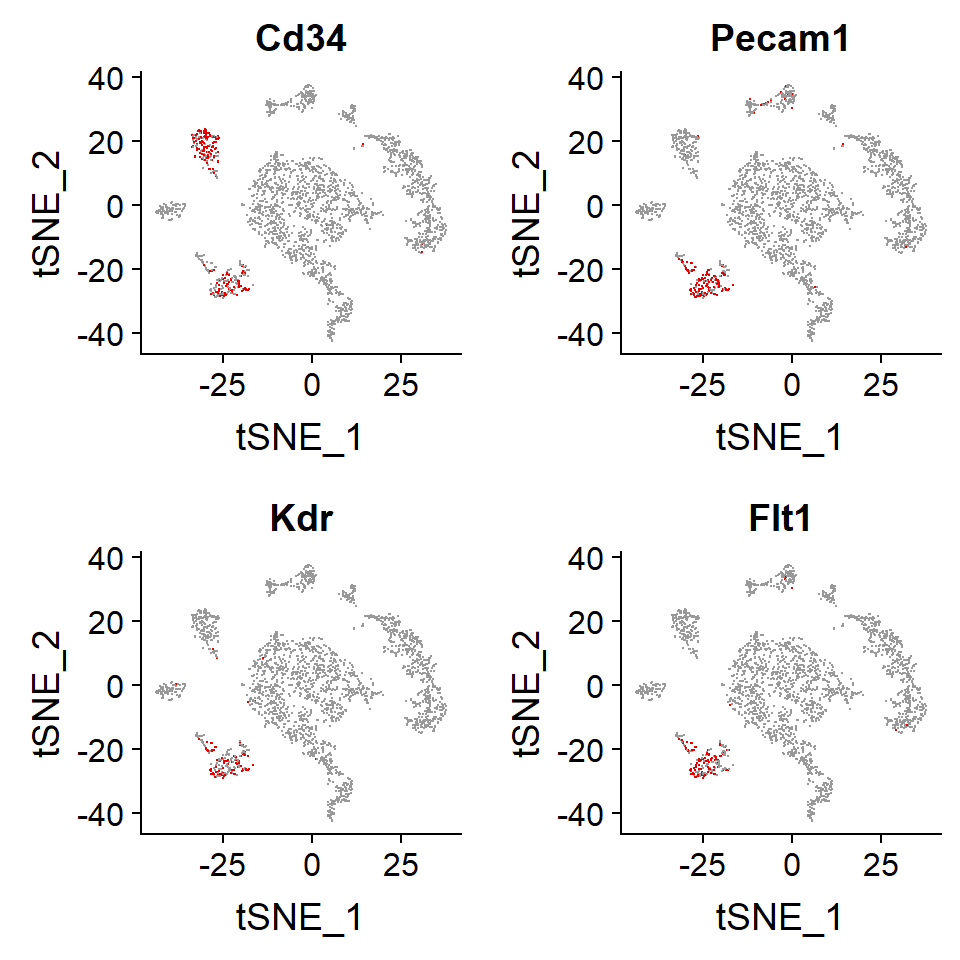

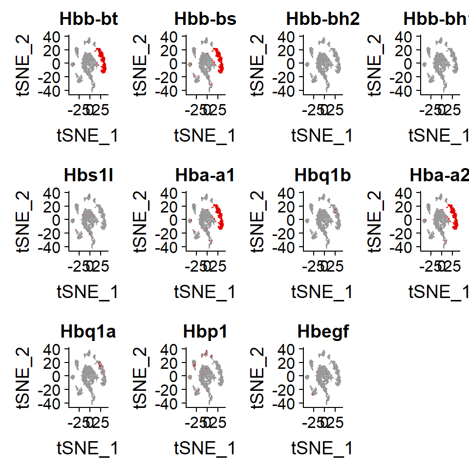

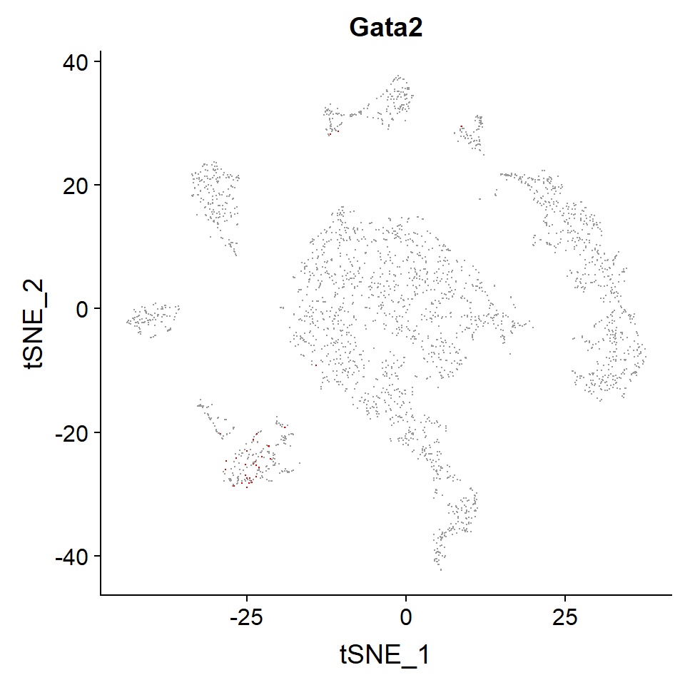

### Find markers in each group

Top 10 markers of each cluster.

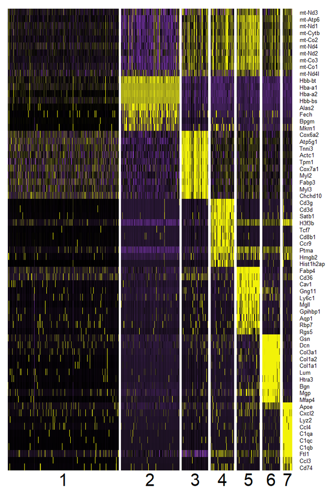

Differentially expression stats.

|  | p_val | avg_logFC | pct.1 | pct.2 | p_val_adj | cluster | gene |
| --- | --- | --- | --- | --- | --- | --- | --- |
| mt-Nd3 | 0 | 2.04748739136192 | 0.999 | 0.863 | 0 | 1 | mt-Nd3 |
| mt-Atp6 | 0 | 2.00661595737415 | 1 | 1 | 0 | 1 | mt-Atp6 |
| mt-Nd1 | 0 | 1.98451661259129 | 1 | 1 | 0 | 1 | mt-Nd1 |
| mt-Cytb | 0 | 1.97792894449937 | 1 | 1 | 0 | 1 | mt-Cytb |
| mt-Co2 | 0 | 1.969334010504 | 1 | 1 | 0 | 1 | mt-Co2 |
| mt-Nd4 | 0 | 1.96247330386049 | 1 | 0.998 | 0 | 1 | mt-Nd4 |
| mt-Nd2 | 0 | 1.92771971571031 | 1 | 0.981 | 0 | 1 | mt-Nd2 |
| mt-Co3 | 0 | 1.92362309575557 | 1 | 1 | 0 | 1 | mt-Co3 |
| mt-Co1 | 0 | 1.91989338949475 | 1 | 1 | 0 | 1 | mt-Co1 |
| mt-Nd4l | 0 | 1.64794576730389 | 0.996 | 0.671 | 0 | 1 | mt-Nd4l |

[output cut: 1361 more lines]

## 2. SIMLR clustering

The cells were clustering using [SIMLR,2017](http://dx.doi.org/10.1038/nmeth.4207). The top 20 PCs were used as imput.

2-D embedding.

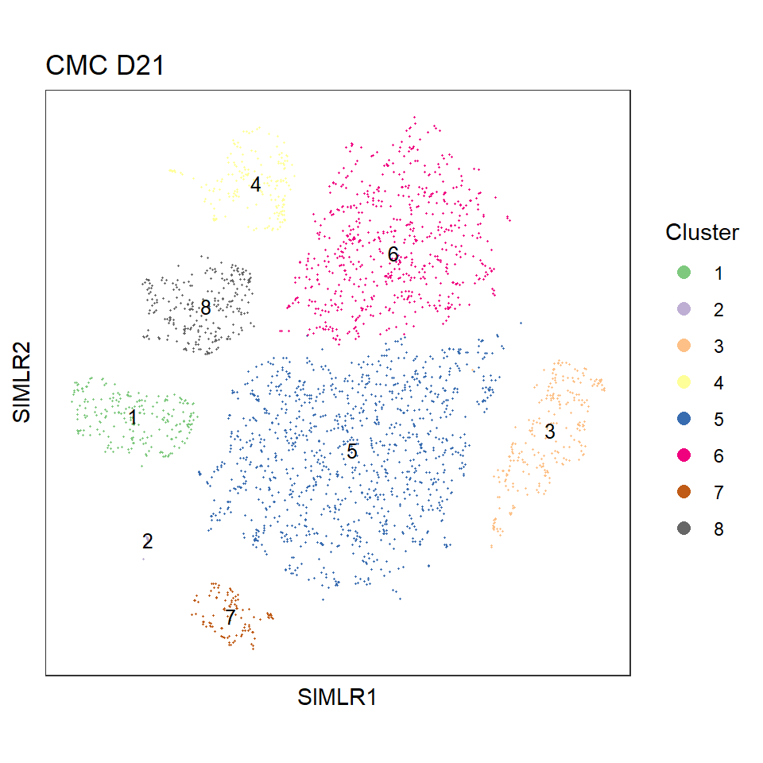

### Find markers in each group

Heatmap of the top 10 markers ranked by logFC using *bimod* test.

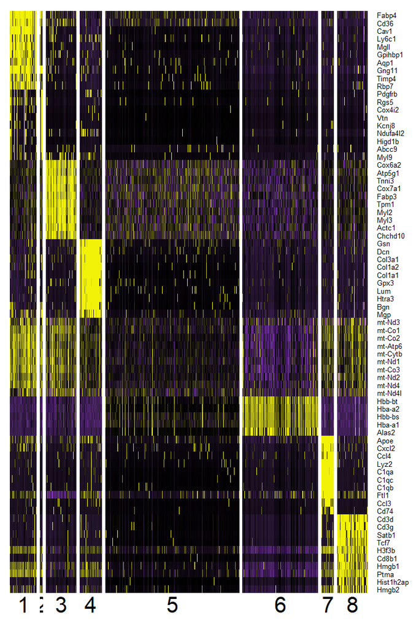

Differentially expression stats.

|  | p_val | avg_logFC | pct.1 | pct.2 | p_val_adj | cluster | gene |
| --- | --- | --- | --- | --- | --- | --- | --- |
| Fabp4 | 0 | 3.78665492248457 | 0.972 | 0.362 | 0 | 1 | Fabp4 |
| Cd36 | 1.10439578935757e-270 | 2.47857130561294 | 0.926 | 0.254 | 1.48817332615933e-266 | 1 | Cd36 |
| Cav1 | 3.71745626997663e-251 | 2.58573537016456 | 0.935 | 0.053 | 5.0092723237935e-247 | 1 | Cav1 |
| Egfl7 | 2.97223902191299e-243 | 2.19540906773282 | 0.926 | 0.04 | 4.00509208202776e-239 | 1 | Egfl7 |
| Ly6c1 | 2.28779251541683e-223 | 2.813530663667 | 0.899 | 0.114 | 3.08280041452418e-219 | 1 | Ly6c1 |
| Cav2 | 1.81070899619225e-222 | 1.88745745128828 | 0.885 | 0.022 | 2.43993037236906e-218 | 1 | Cav2 |
| Sdpr | 1.21800516179918e-217 | 2.18174769568498 | 0.903 | 0.054 | 1.64126195552439e-213 | 1 | Sdpr |
| Mgll | 2.98559154712757e-217 | 2.30449035640969 | 0.862 | 0.038 | 4.02308460975441e-213 | 1 | Mgll |
| Cdh5 | 6.31120734645017e-207 | 1.86746514123287 | 0.848 | 0.023 | 8.5043518993416e-203 | 1 | Cdh5 |
| Gpihbp1 | 1.3801134946975e-206 | 2.62683328824145 | 0.834 | 0.062 | 1.85970293410489e-202 | 1 | Gpihbp1 |

[output cut: 1484 more lines]